# cryptography course project

Dynasty

2022-07-15

```r
knitr::opts_chunk$set(echo = TRUE)
```

# **Introduction**

A Kenyan entrepreneur has created an online cryptography course and would want to advertise it on her blog. She currently targets audiences originating from various countries. In the past, she ran ads to advertise a related course on the same blog and collected data in the process. The columns in the data set include: * Daily_Time_Spent_on_Site

```
  * Age

  * Area_Income

  * Daily_Internet_Usage

  * Ad_Topic_Line

  * City

  * Male

  * Country

  * Time stamp

  * Clicked_on_Ad
```

She would now like to employ your services as a Data Science Consultant to help her identify which individuals are most likely to click on her ads.

### **Metrics of Success**

1. Define the question, the metric for success, the context, experimental design taken and the appropriateness of the available data to answer the given question.
2. Find and deal with outliers, anomalies, and missing data within the data set.
3. Perform uni variate and bivariate analysis.
4. From your insights provide a conclusion and recommendation.

## **Loading our data set**

```r
library(data.table)
advert <- fread('http://bit.ly/IPAdvertisingData')
```

Now let’s preview our dataset

#### First six rows

```r
head(advert)
```

```
##    Daily Time Spent on Site Age Area Income Daily Internet Usage
## 1:                    68.95  35    61833.90               256.09
## 2:                    80.23  31    68441.85               193.77
## 3:                    69.47  26    59785.94               236.50
## 4:                    74.15  29    54806.18               245.89
## 5:                    68.37  35    73889.99               225.58
## 6:                    59.99  23    59761.56               226.74
##                            Ad Topic Line           City Male    Country
## 1:    Cloned 5thgeneration orchestration    Wrightburgh    0    Tunisia
## 2:    Monitored national standardization      West Jodi    1      Nauru
## 3:      Organic bottom-line service-desk       Davidton    0 San Marino
## 4: Triple-buffered reciprocal time-frame West Terrifurt    1      Italy
## 5:         Robust logistical utilization   South Manuel    0    Iceland
## 6:       Sharable client-driven software      Jamieberg    1     Norway
##              Timestamp Clicked on Ad
## 1: 2016-03-27 00:53:11             0
## 2: 2016-04-04 01:39:02             0
## 3: 2016-03-13 20:35:42             0
## 4: 2016-01-10 02:31:19             0
## 5: 2016-06-03 03:36:18             0
## 6: 2016-05-19 14:30:17             0
```

Will check the class or datatypes in the data set

```r
str(advert)
```

```
## Classes 'data.table' and 'data.frame':   1000 obs. of  10 variables:
##  $ Daily Time Spent on Site: num  69 80.2 69.5 74.2 68.4 ...
##  $ Age                     : int  35 31 26 29 35 23 33 48 30 20 ...
##  $ Area Income             : num  61834 68442 59786 54806 73890 ...
##  $ Daily Internet Usage    : num  256 194 236 246 226 ...
##  $ Ad Topic Line           : chr  "Cloned 5thgeneration orchestration" "Monitored national standardization" "Organic bottom-line service-desk" "Triple-buffered reciprocal time-frame" ...
##  $ City                    : chr  "Wrightburgh" "West Jodi" "Davidton" "West Terrifurt" ...
##  $ Male                    : int  0 1 0 1 0 1 0 1 1 1 ...
##  $ Country                 : chr  "Tunisia" "Nauru" "San Marino" "Italy" ...
##  $ Timestamp               : POSIXct, format: "2016-03-27 00:53:11" "2016-04-04 01:39:02" ...
##  $ Clicked on Ad           : int  0 0 0 0 0 0 0 1 0 0 ...
##  - attr(*, ".internal.selfref")=<externalptr>
```

Lets check number of rows and columns

```r
dim(advert)
```

```
## [1] 1000   10
```

Data set attributes

```r
class(advert)
```

```
## [1] "data.table" "data.frame"
```

## **Data Cleaning and Data Preparation**

1. checking for nulls/missing values

```r
is.null(advert)
```

```
## [1] FALSE
```

we don’t have null values.

2. Checking for duplicates

```r
duplicated_rows <- advert[duplicated(advert),]
duplicated_rows
```

```
## Empty data.table (0 rows and 10 cols): Daily Time Spent on Site,Age,Area Income,Daily Internet Usage,Ad Topic Line,City...
```

We have no duplicates

3. Checking for outliers

We have four numeric columns so will check outliers in them

```r
library(tidyverse)
```

Let’s see if we have any outliers in age, as the boxplot shows we have no outliers

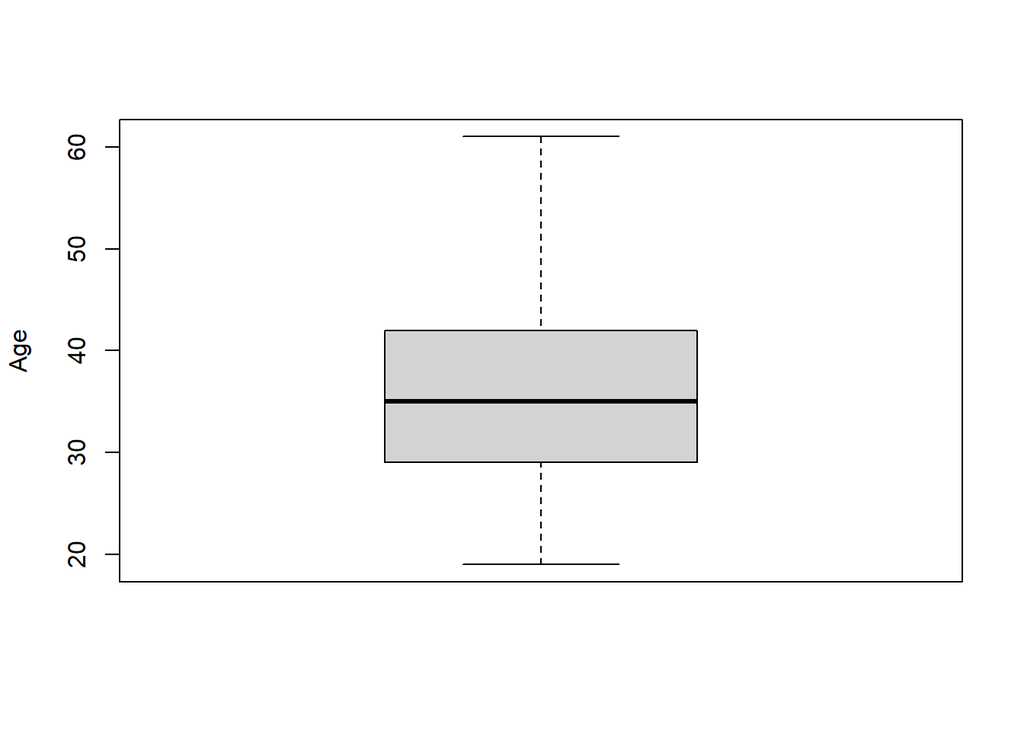

```r
boxplot(advert$Age, ylab = "Age")
```

Let’s see if we have outliers in area income

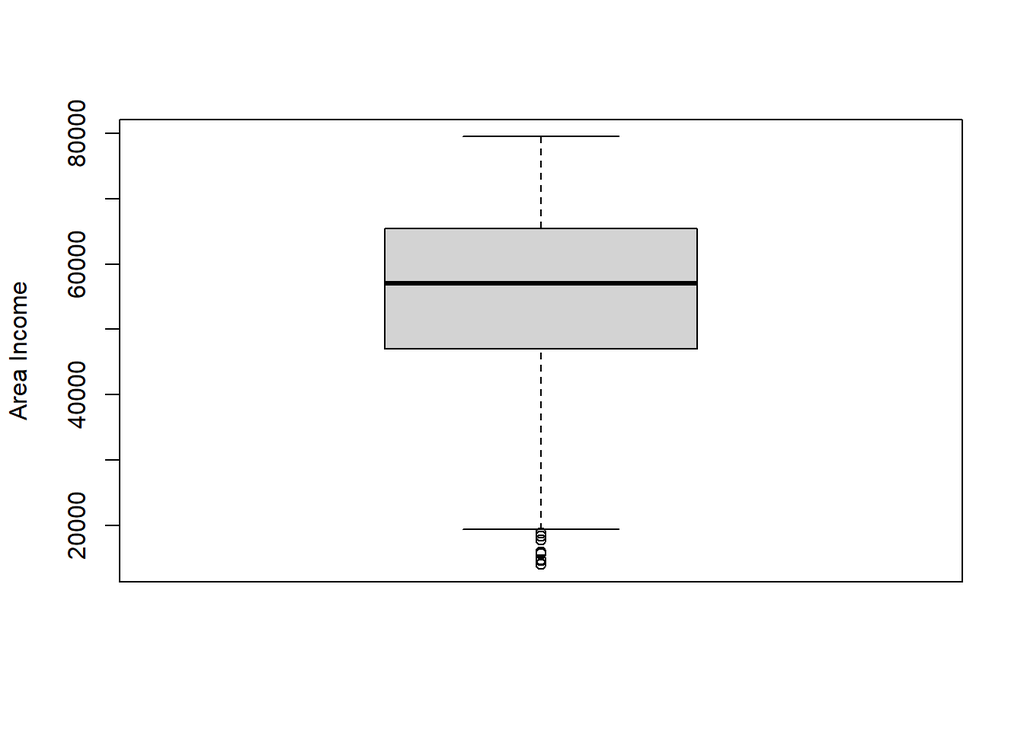

```r
boxplot(advert$`Area Income`, ylab = "Area Income")
```

Let’s check for outliers in Daily internal usage, we have no outliers as the graph shows

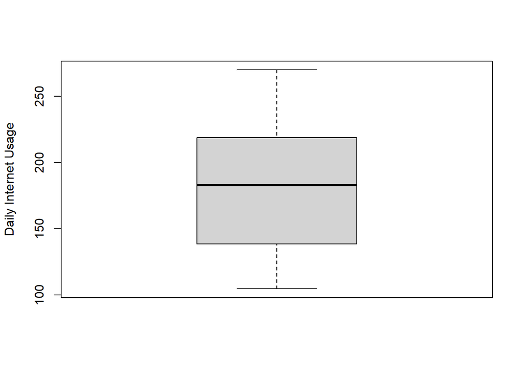

```r
boxplot(advert$`Daily Internet Usage`, ylab = "Daily Internet Usage")
```

Let’s check for outliers inthe last numeric column

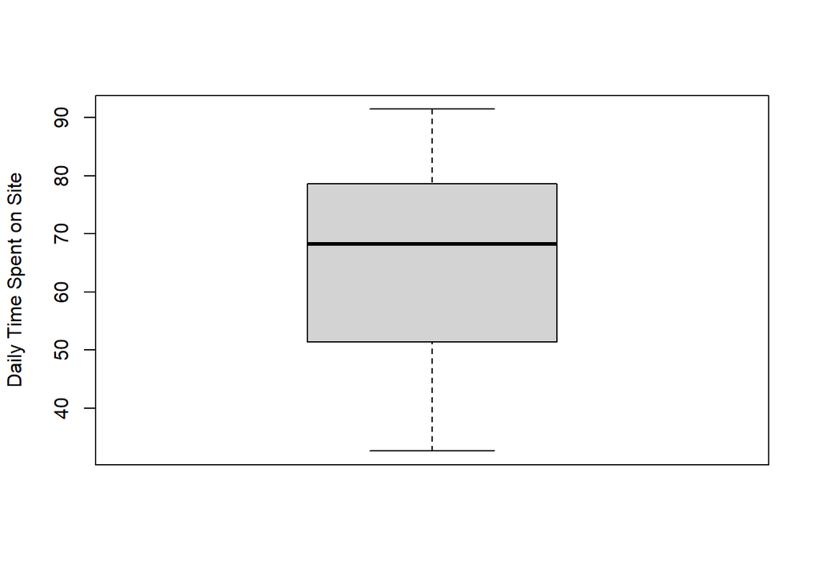

```r
boxplot(advert$`Daily Time Spent on Site`, ylab = "Daily Time Spent on Site")
```

# **Exploratory Data Analysis**

### **1. Uni variate Analysis**

Now well move to exploratory data analysis

Age

1. Let’s see the mean age of the the audience in our client’s blog

```r
age.mean <- mean(advert$Age)
age.mean
```

```
## [1] 36.009
```

The mean age of most audience is around the age of 36 years

2. Let’s see the age range

```r
age.range <- range(advert$Age)
age.range
```

```
## [1] 19 61
```

We can see most of the audience age range is between 19 to 61 years.

3. Let’s see what most of the audiences age bracket is

```r
getmode <- function(v) {
   uniqv <- unique(v)
   uniqv[which.max(tabulate(match(v, uniqv)))]
}
```

```r
age.mode <- getmode(advert$Age)
age.mode
```

```
## [1] 31
```

Most of the audience are 31 years

Visualizing these results

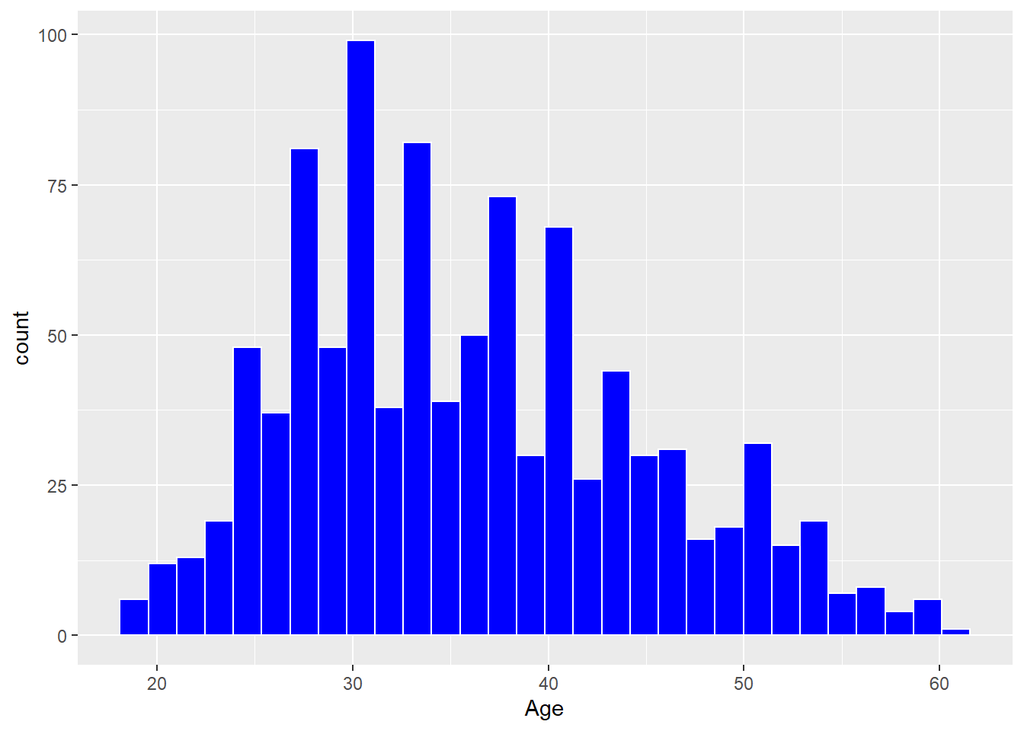

```r
ggplot(advert, aes(x=Age)) + geom_histogram(color="white", fill="blue")
```

4. Let’s check country where most of the audiences come from

```r
country.mode <- getmode(advert$Country)
country.mode
```

```
## [1] "Czech Republic"
```

Most audiences come from Czech Republic.

```r
country.min <- min(advert$Country)
country.min
```

```
## [1] "Afghanistan"
```

6. Let’s also check the city with most audiences

```r
city.mode <- getmode(advert$City)
city.mode
```

```
## [1] "Lisamouth"
```

```r
city.min <- min(advert$City)
city.min
```

```
## [1] "Adamsbury"
```

8. We can also check the frequent Ad line topic

```r
topic.mode <- getmode(advert$`Ad Topic Line`)
topic.mode
```

```
## [1] "Cloned 5thgeneration orchestration"
```

```r
topic.min <- min(advert$`Ad Topic Line`)
topic.min
```

```
## [1] "Adaptive 24hour Graphic Interface"
```

10. Let’s see mean daily time spent on site

```r
time.mean <- mean(advert$`Daily Time Spent on Site`)
time.mean
```

```
## [1] 65.0002
```

11. Let’s check the range of time spent on site daily

```r
time.range <- range(advert$`Daily Time Spent on Site`)
time.range
```

```
## [1] 32.60 91.43
```

Will visualize these in a histogram

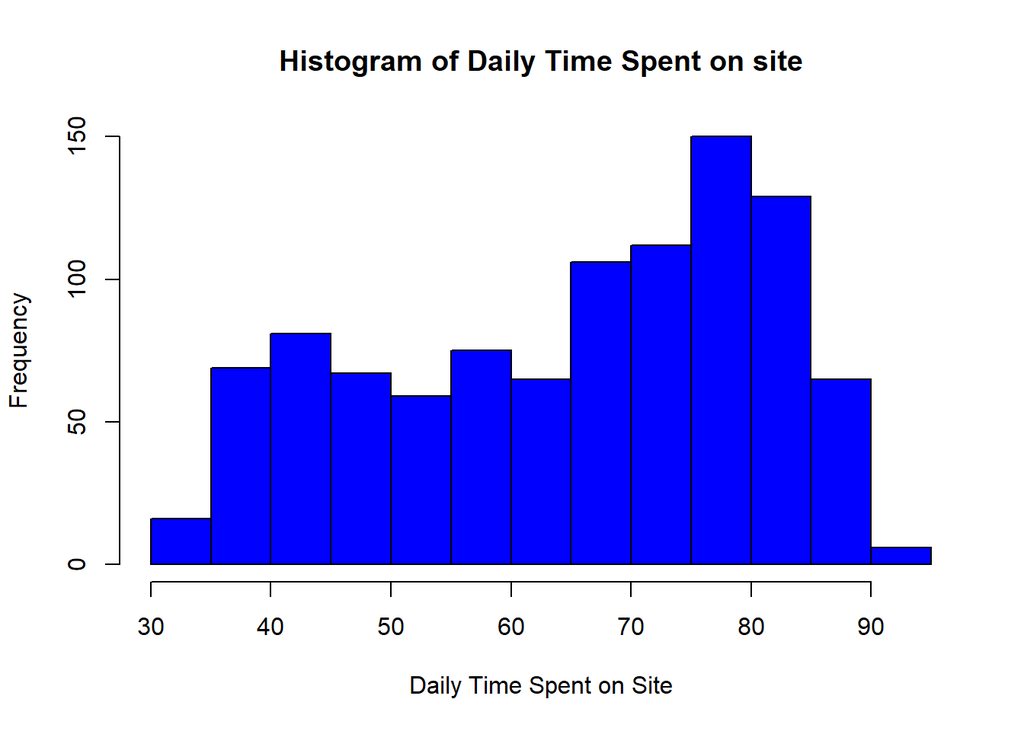

```r
hist((advert$`Daily Time Spent on Site`),
main = "Histogram of Daily Time Spent on site",
     xlab = 'Daily Time Spent on Site',
     ylab = 'Frequency',
     col = "blue")
```

12. determining mean area income

```r
area.mean <- mean(advert$`Area Income`)
area.mean
```

```
## [1] 55000
```

13. Range of area income

```r
area.range <- range(advert$`Area Income`)
area.range
```

```
## [1] 13996.5 79484.8
```

Visualize these results

[figure not shown]

```r
hist((advert$`Area Income`),
main = "Histogram of Daily Intenet Usage",
     xlab = 'Area Income',
     ylab = 'Frequency',
     col = "blue")
```

14. Determining mean Daily internet usage

```r
usage.mean <- mean(advert$`Daily Internet Usage`)
usage.mean
```

```
## [1] 180.0001
```

15. range of internet usage daily

```r
usage.range <- range(advert$`Daily Internet Usage`)
usage.range
```

```
## [1] 104.78 269.96
```

Will visualize this below

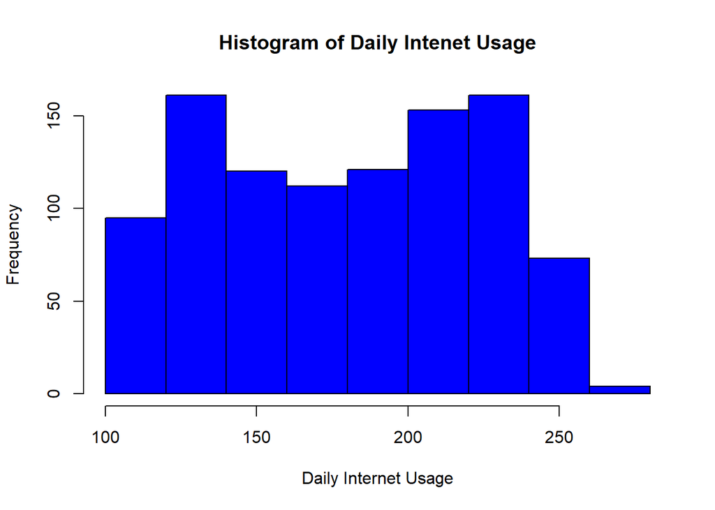

```r
hist((advert$`Daily Internet Usage`),
main = "Histogram of Daily Intenet Usage",
     xlab = 'Daily Internet Usage',
     ylab = 'Frequency',
     col = "blue")
```

16. Now let’s visualize gender distribution

```r
gender <- (advert$Male)
gender.frequency <- table(gender)
gender.frequency
```

```
## gender
##   0   1
## 519 481
```